# House prices in Iowa: Application of Regression Analysis Techniques

Kazeem Tijani & Jake Miranda

# 1 Introduction

This project is for STAT 5120- Regression Analysis, We seek to apply all the knowledge acquired in the class to perform exploratory data analysis, data visualization and predictive modelling on the Iowa Housing Data.The dataset used can be found on Kaggle by clicking [here](https://www.kaggle.com/c/house-prices-advanced-regression-techniques)

We decided to work on this project to unravel the application of regression analysis techniques to building a real life predictive model that we can use to make decision on possible amount to sell houses which we feel can be a product developed to help realtors while we serve as business consultant or possibly develop a software that can be use the disrupt the real estate market.

Ask a home buyer to describe their dream house, and they probably won’t begin with the height of the basement ceiling or the proximity to an east-west railroad. But this playground competition’s dataset proves that much more influences price negotiations than the number of bedrooms or a white-picket fence. The dataset we used is very rich, comprising 79 explanatory variables describing almost every aspect of residential apartments in Ames, Iowa.

We seek to build our model on the training set and then predict the final price of each home on our test set.

With 79 explanatory variables describing (almost) every aspect of residential homes in Ames, Iowa, this competition challenges you to predict the final price of each home.

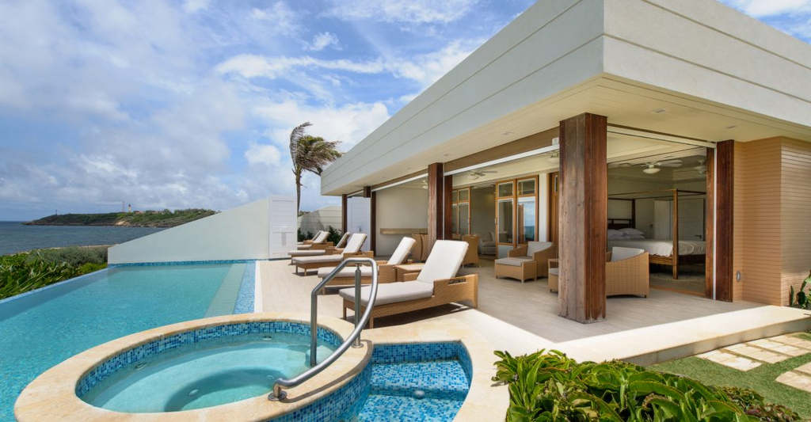

Loading R packages used besides base R.

```r
library(knitr)
library(ggplot2)
library(plyr)
library(dplyr)
library(corrplot)
library(caret)
library(gridExtra)
library(scales)
library(Rmisc)
library(ggrepel)
```

Here, we import the training and test datasets into R.

```r
training_set <- read.csv("C:/Users/HP Laptop/Desktop/stat5120project/train.csv", na.strings = "NA", header = TRUE)
test_set <- read.csv("C:/Users/HP Laptop/Desktop/stat5120project/test.csv", na.strings = "NA", header = TRUE)
```

## 1.1 Data size and structure

The train dataset consist of character and integer variables. Most of the character variables are actually (ordinal) factors, but I chose to read them into R as character strings as most of them require cleaning and/or feature engineering first. In total, there are 81 columns/variables, of which the last one is the response variable (SalePrice). Below, I am displaying only a glimpse of the variables. All of them are discussed in more detail throughout the document.

```r
dim(training_set)
```

```
## [1] 1460   81
```

```r
str(training_set[,c(1:10, 81)]) #display first 10 variables and the response variable
```

```
## 'data.frame':    1460 obs. of  11 variables:
##  $ Id         : int  1 2 3 4 5 6 7 8 9 10 ...
##  $ MSSubClass : int  60 20 60 70 60 50 20 60 50 190 ...
##  $ MSZoning   : Factor w/ 5 levels "C (all)","FV",..: 4 4 4 4 4 4 4 4 5 4 ...
##  $ LotFrontage: int  65 80 68 60 84 85 75 NA 51 50 ...
##  $ LotArea    : int  8450 9600 11250 9550 14260 14115 10084 10382 6120 7420 ...
##  $ Street     : Factor w/ 2 levels "Grvl","Pave": 2 2 2 2 2 2 2 2 2 2 ...
##  $ Alley      : Factor w/ 2 levels "Grvl","Pave": NA NA NA NA NA NA NA NA NA NA ...
##  $ LotShape   : Factor w/ 4 levels "IR1","IR2","IR3",..: 4 4 1 1 1 1 4 1 4 4 ...
##  $ LandContour: Factor w/ 4 levels "Bnk","HLS","Low",..: 4 4 4 4 4 4 4 4 4 4 ...
##  $ Utilities  : Factor w/ 2 levels "AllPub","NoSeWa": 1 1 1 1 1 1 1 1 1 1 ...
##  $ SalePrice  : int  208500 181500 223500 140000 250000 143000 307000 200000 129900 118000 ...
```

```r
#Getting rid of the IDs but keeping the test IDs in a vector. These are needed to compose the submission file
test_labels <- test_set$Id
test_set$Id <- NULL
training_set$Id <- NULL
```

```r
test_set$SalePrice <- NA
all <- rbind(training_set, test_set)
dim(all)
```

```
## [1] 2919   80
```

Without the Id’s, the dataframe consists of 79 predictors and our response variable SalePrice.

We would like to observe the SalePrice, and check the shape as the basic exploratory data analysis, As you can see, the sale prices are right skewed. This was expected as few people can afford very expensive houses. I will keep this in mind, and take measures before modeling.

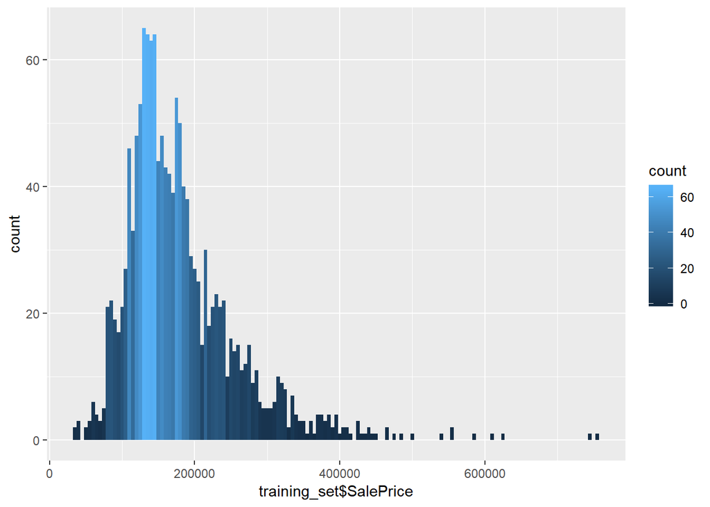

```r
# Let's observe our response variable in this case which is the SalePrice
options(scipen = 1000)
ggplot(training_set, aes(training_set$SalePrice, fill = ..count..))+geom_histogram(binwidth = 5000)
```

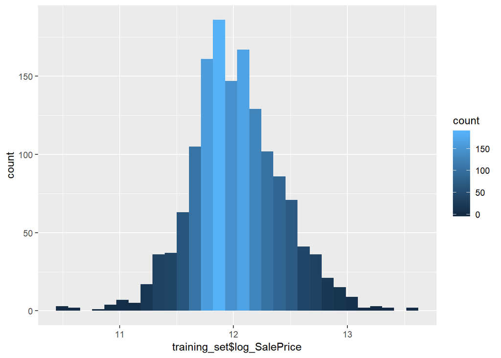

```r
# Let's try to make the plot more normally distributed by using the log
training_set$log_SalePrice <- log(training_set$SalePrice)
ggplot(training_set, aes(training_set$log_SalePrice, fill = ..count..))+geom_histogram()
```

## 1.2 The most important numeric predictors

The character variables need some work before I can use them. To get a feel for the dataset, I decided to first see which numeric variables have a high correlation with the SalePrice.

### 1.2.1 Correlations with SalePrice

Altogether, there are 10 numeric variables with a correlation of at least 0.5 with SalePrice. All those correlations are positive.

```r
numericVars <- which(sapply(training_set, is.numeric)) #index vector numeric variables
numericVarNames <- names(numericVars) #saving names vector for use later on
cat('There are', length(numericVars), 'numeric variables')
```

```
## There are 38 numeric variables
```

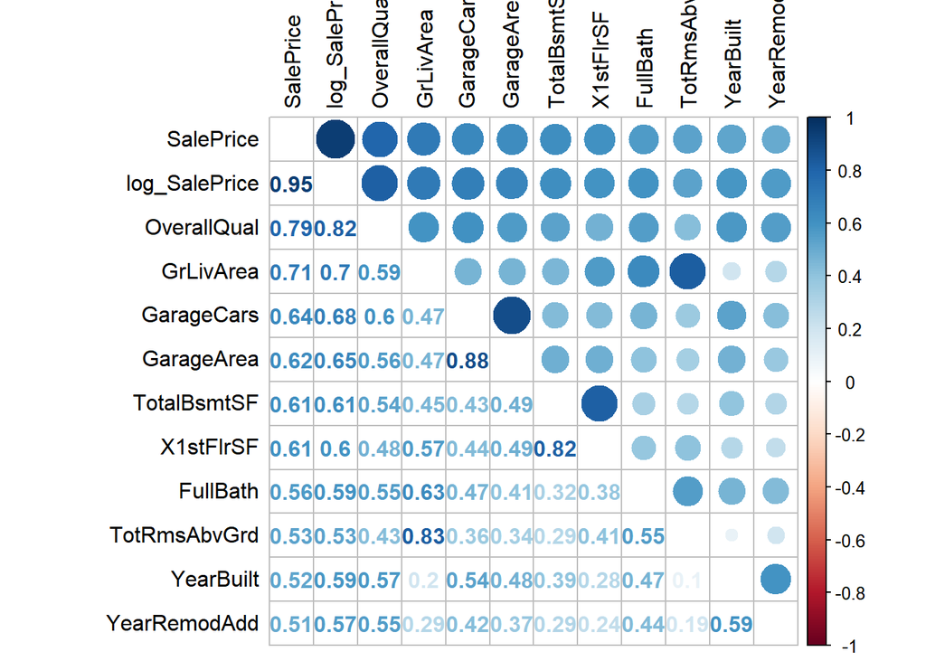

```r
all_numVar <- training_set[, numericVars]
cor_numVar <- cor(all_numVar, use="pairwise.complete.obs") #correlations of all numeric variables

#sort on decreasing correlations with SalePrice
cor_sorted <- as.matrix(sort(cor_numVar[,'SalePrice'], decreasing = TRUE))
 #select only high corelations
CorHigh <- names(which(apply(cor_sorted, 1, function(x) abs(x)>0.5)))
cor_numVar <- cor_numVar[CorHigh, CorHigh]

corrplot.mixed(cor_numVar, tl.col="black", tl.pos = "lt")
```

We decided to select variables that appear interesting to us, instead of using all the variables

```r
# Selecting the important variables
importantVar<- c('MSZoning', 'LotArea', 'Utilities', 'Neighborhood', 'BldgType',
               'HouseStyle', 'OverallQual','OverallCond', 'YearBuilt', 'ExterQual',
               'HeatingQC', 'CentralAir', 'GrLivArea', 'FullBath', 'TotRmsAbvGrd',
               'KitchenQual', 'GarageCars',
               'GarageArea','OpenPorchSF','PoolArea','SalePrice')
newTrainingSet <- training_set[,importantVar]
head(newTrainingSet)
```

```
##   MSZoning LotArea Utilities Neighborhood BldgType HouseStyle OverallQual
## 1       RL    8450    AllPub      CollgCr     1Fam     2Story           7
## 2       RL    9600    AllPub      Veenker     1Fam     1Story           6
## 3       RL   11250    AllPub      CollgCr     1Fam     2Story           7
## 4       RL    9550    AllPub      Crawfor     1Fam     2Story           7
## 5       RL   14260    AllPub      NoRidge     1Fam     2Story           8
## 6       RL   14115    AllPub      Mitchel     1Fam     1.5Fin           5
##   OverallCond YearBuilt ExterQual HeatingQC CentralAir GrLivArea FullBath
## 1           5      2003        Gd        Ex          Y      1710        2
## 2           8      1976        TA        Ex          Y      1262        2
## 3           5      2001        Gd        Ex          Y      1786        2
## 4           5      1915        TA        Gd          Y      1717        1
## 5           5      2000        Gd        Ex          Y      2198        2
## 6           5      1993        TA        Ex          Y      1362        1
##   TotRmsAbvGrd KitchenQual GarageCars GarageArea OpenPorchSF PoolArea
## 1            8          Gd          2        548          61        0
## 2            6          TA          2        460           0        0
## 3            6          Gd          2        608          42        0
## 4            7          Gd          3        642          35        0
## 5            9          Gd          3        836          84        0
## 6            5          TA          2        480          30        0
##   SalePrice
## 1    208500
## 2    181500
## 3    223500
## 4    140000
## 5    250000
## 6    143000
```

# 2 label encoding, and factorizing variables

### 2.0.1 First, we would like to classify the data and then convert some of the factors to numeric variable

```r
# Getting the classification of the data
numericVars <- which(sapply(newTrainingSet, is.numeric)) #index vector numeric variables
factorVars <- which(sapply(newTrainingSet, is.factor))

# Converting Factors to Numeric
newTrainingSet$ExterQual <- as.numeric(factor(newTrainingSet$ExterQual, levels = c("Ex","Gd","TA","Fa","Po"),labels = c(5,4,3,2,1), ordered = T))
newTrainingSet$HeatingQC <- as.numeric(factor(newTrainingSet$HeatingQC, levels = c("Ex","Gd","TA","Fa","Po"),labels = c(5,4,3,2,1), ordered = T))
newTrainingSet$CentralAir <- as.numeric(factor(newTrainingSet$CentralAir, levels = c("N","Y"),labels = c(0,1),ordered = T))
newTrainingSet$KitchenQual <- as.numeric(factor(newTrainingSet$KitchenQual, levels = c("Ex","Gd","TA","Fa","Po"),labels = c(5,4,3,2,1), ordered = T))
```

We continue to deal with the categorical variables, so as to make it easier to build our model.We would have preferred to do one-hot encoding on the categorical data but we couldnt handle that correctly that was why used this approach to capture the categorical data

```r
newTrainingSet$MSZoning <-as.numeric(factor(newTrainingSet$MSZoning))
newTrainingSet$Neighborhood <- as.numeric(factor(newTrainingSet$Neighborhood))
newTrainingSet$Utilities <- as.numeric(factor(newTrainingSet$Utilities))
newTrainingSet$BldgType <- as.numeric(factor(newTrainingSet$BldgType))
newTrainingSet$HouseStyle <- as.numeric(factor(newTrainingSet$HouseStyle))
```

# 3 Predictive Modeling

We would perform the linear regression model on our the newTrainig data after we have done the date preprocessing, we build our regression model and see how well our model behaves.

```r
#naCol <- which(colSums(is.na(newTrainingSet))>0)
#sort(colSums(sapply(newTrainingSet[naCol],is.na)), decreasing = T)
```

```r
head(newTrainingSet)
```

```
##   MSZoning LotArea Utilities Neighborhood BldgType HouseStyle OverallQual
## 1        4    8450         1            6        1          6           7
## 2        4    9600         1           25        1          3           6
## 3        4   11250         1            6        1          6           7
## 4        4    9550         1            7        1          6           7
## 5        4   14260         1           14        1          6           8
## 6        4   14115         1           12        1          1           5
##   OverallCond YearBuilt ExterQual HeatingQC CentralAir GrLivArea FullBath
## 1           5      2003         2         1          2      1710        2
## 2           8      1976         3         1          2      1262        2
## 3           5      2001         2         1          2      1786        2
## 4           5      1915         3         2          2      1717        1
## 5           5      2000         2         1          2      2198        2
## 6           5      1993         3         1          2      1362        1
##   TotRmsAbvGrd KitchenQual GarageCars GarageArea OpenPorchSF PoolArea
## 1            8           2          2        548          61        0
## 2            6           3          2        460           0        0
## 3            6           2          2        608          42        0
## 4            7           2          3        642          35        0
## 5            9           2          3        836          84        0
## 6            5           3          2        480          30        0
##   SalePrice
## 1    208500
## 2    181500
## 3    223500
## 4    140000
## 5    250000
## 6    143000
```

```r
lmod <- lm(newTrainingSet$SalePrice ~ .,na.action = na.omit, data = newTrainingSet)
summary(lmod)
```

```
##
## Call:
## lm(formula = newTrainingSet$SalePrice ~ ., data = newTrainingSet,
##     na.action = na.omit)
##
## Residuals:
##     Min      1Q  Median      3Q     Max
## -417805  -18569    -990   14498  293492
##
## Coefficients:
##                  Estimate   Std. Error t value             Pr(>|t|)
## (Intercept)  -867141.8018  123164.4892  -7.041 0.000000000002956350 ***
## MSZoning         602.1428    1667.5804   0.361              0.71809
## LotArea            0.7109       0.1023   6.950 0.000000000005525342 ***
## Utilities     -32383.8206   36641.7511  -0.884              0.37695
## Neighborhood     310.5371     171.3408   1.812              0.07013 .
## BldgType       -4907.4602     878.4561  -5.586 0.000000027672544544 ***
## HouseStyle     -2297.6932     552.1397  -4.161 0.000033498889130717 ***
## OverallQual    16092.4543    1251.9726  12.854 < 0.0000000000000002 ***
## OverallCond     4589.7906    1024.9604   4.478 0.000008128944292768 ***
## YearBuilt        478.2180      58.2122   8.215 0.000000000000000467 ***
## ExterQual     -15508.9159    2888.7648  -5.369 0.000000092343895371 ***
## HeatingQC        133.0444    1251.8745   0.106              0.91538
## CentralAir     -3356.9992    4535.9817  -0.740              0.45937
## GrLivArea         59.2867       4.0979  14.468 < 0.0000000000000002 ***
## FullBath       -7057.9544    2596.9327  -2.718              0.00665 **
## TotRmsAbvGrd   -1060.9547    1100.0454  -0.964              0.33498
## KitchenQual   -12549.0157    2269.6200  -5.529 0.000000038164914934 ***
## GarageCars      9359.9357    2948.9816   3.174              0.00154 **
## GarageArea        13.6685       9.9458   1.374              0.16956
## OpenPorchSF       -7.1757      15.7450  -0.456              0.64864
## PoolArea         -15.4967      24.5135  -0.632              0.52738
## ---
## Signif. codes:  0 '***' 0.001 '**' 0.01 '*' 0.05 '.' 0.1 ' ' 1
##
## Residual standard error: 36410 on 1439 degrees of freedom
## Multiple R-squared:  0.7928, Adjusted R-squared:   0.79
## F-statistic: 275.4 on 20 and 1439 DF,  p-value: < 0.00000000000000022
```

We would like to perform stepwise regression so as to know what variables have greater contributions to the model

```r
trainModel <- step(lmod)
```

```
## Start:  AIC=30688.27
## newTrainingSet$SalePrice ~ MSZoning + LotArea + Utilities + Neighborhood +
##     BldgType + HouseStyle + OverallQual + OverallCond + YearBuilt +
##     ExterQual + HeatingQC + CentralAir + GrLivArea + FullBath +
##     TotRmsAbvGrd + KitchenQual + GarageCars + GarageArea + OpenPorchSF +
##     PoolArea
##
##                Df    Sum of Sq           RSS   AIC
## - HeatingQC     1     14971470 1907467323654 30686
## - MSZoning      1    172829706 1907625181890 30686
## - OpenPorchSF   1    275316238 1907727668421 30687
## - PoolArea      1    529736622 1907982088806 30687
## - CentralAir    1    726027016 1908178379199 30687
## - Utilities     1   1035372519 1908487724703 30687
## - TotRmsAbvGrd  1   1233006477 1908685358661 30687
## - GarageArea    1   2503577359 1909955929542 30688
## <none>                         1907452352184 30688
## - Neighborhood  1   4354099488 1911806451671 30690
## - FullBath      1   9791048691 1917243400875 30694
## - GarageCars    1  13353481061 1920805833245 30697
## - HouseStyle    1  22955095538 1930407447722 30704
## - OverallCond   1  26580582100 1934032934284 30707
## - ExterQual     1  38205986555 1945658338739 30715
## - KitchenQual   1  40523405416 1947975757599 30717
## - BldgType      1  41368178343 1948820530526 30718
## - LotArea       1  64024260794 1971476612977 30735
## - YearBuilt     1  89457471449 1996909823633 30753
## - OverallQual   1 219001869171 2126454221354 30845
## - GrLivArea     1 277449735120 2184902087303 30885
##
## Step:  AIC=30686.28
## newTrainingSet$SalePrice ~ MSZoning + LotArea + Utilities + Neighborhood +
##     BldgType + HouseStyle + OverallQual + OverallCond + YearBuilt +
##     ExterQual + CentralAir + GrLivArea + FullBath + TotRmsAbvGrd +
##     KitchenQual + GarageCars + GarageArea + OpenPorchSF + PoolArea
##
##                Df    Sum of Sq           RSS   AIC
## - MSZoning      1    179349220 1907646672874 30684
## - OpenPorchSF   1    277526860 1907744850514 30685
## - PoolArea      1    517831792 1907985155446 30685
```

[output cut: 168 more lines]

```
##
##                Df    Sum of Sq           RSS   AIC
## <none>                         1913825853655 30677
## - Neighborhood  1   4511743281 1918337596936 30679
## - FullBath      1  12131356128 1925957209783 30684
## - HouseStyle    1  26143587889 1939969441544 30695
## - OverallCond   1  27583437031 1941409290686 30696
## - KitchenQual   1  41345045263 1955170898918 30706
## - ExterQual     1  41440555772 1955266409427 30706
## - BldgType      1  42742628256 1956568481911 30707
## - LotArea       1  66124356957 1979950210612 30725
## - GarageCars    1  68560551770 1982386405425 30727
## - YearBuilt     1 105736660868 2019562514523 30754
## - OverallQual   1 221680534563 2135506388218 30835
## - GrLivArea     1 489395166026 2403221019681 31008
```

```r
summary(trainModel)
```

```
##
## Call:
## lm(formula = newTrainingSet$SalePrice ~ LotArea + Neighborhood +
##     BldgType + HouseStyle + OverallQual + OverallCond + YearBuilt +
##     ExterQual + GrLivArea + FullBath + KitchenQual + GarageCars,
##     data = newTrainingSet, na.action = na.omit)
##
## Residuals:
##     Min      1Q  Median      3Q     Max
## -410362  -18819   -1010   14962  289979
##
## Coefficients:
##                  Estimate   Std. Error t value             Pr(>|t|)
## (Intercept)  -882045.3462  106002.0632  -8.321 < 0.0000000000000002 ***
## LotArea            0.7180       0.1015   7.071    0.000000000002391 ***
## Neighborhood     304.8680     165.0656   1.847               0.0650 .
## BldgType       -4837.3151     850.9239  -5.685    0.000000015818316 ***
## HouseStyle     -2418.8130     544.0473  -4.446    0.000009417875535 ***
## OverallQual    16110.2741    1244.3888  12.946 < 0.0000000000000002 ***
## OverallCond     4434.2300     970.9815   4.567    0.000005373845314 ***
## YearBuilt        467.2920      52.2628   8.941 < 0.0000000000000002 ***
## ExterQual     -15754.2474    2814.5037  -5.598    0.000000025974064 ***
## GrLivArea         56.7352       2.9494  19.236 < 0.0000000000000002 ***
## FullBath       -7607.9815    2512.0699  -3.029               0.0025 **
## KitchenQual   -12483.9505    2232.8382  -5.591    0.000000026937141 ***
## GarageCars     12604.1952    1750.6322   7.200    0.000000000000966 ***
## ---
## Signif. codes:  0 '***' 0.001 '**' 0.01 '*' 0.05 '.' 0.1 ' ' 1
##
## Residual standard error: 36370 on 1447 degrees of freedom
## Multiple R-squared:  0.7922, Adjusted R-squared:  0.7904
## F-statistic: 459.6 on 12 and 1447 DF,  p-value: < 0.00000000000000022
```

## 3.1 Performing Diagnostics

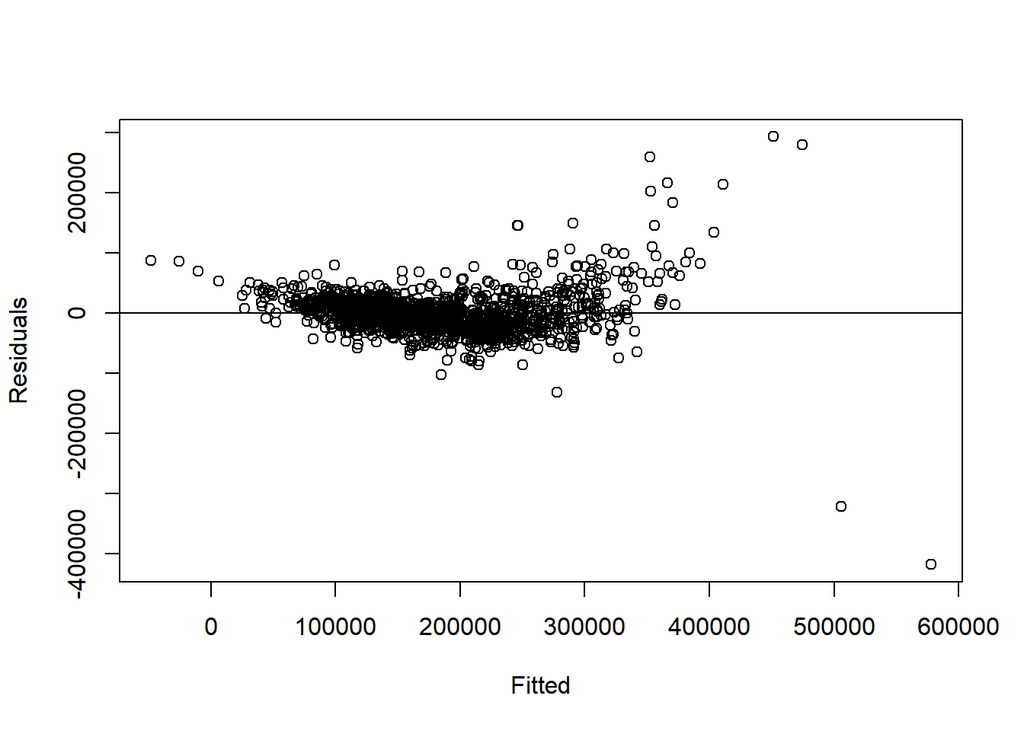

```r
plot(fitted(lmod), residuals(lmod), xlab = "Fitted", ylab = "Residuals")
abline(h=0)
```

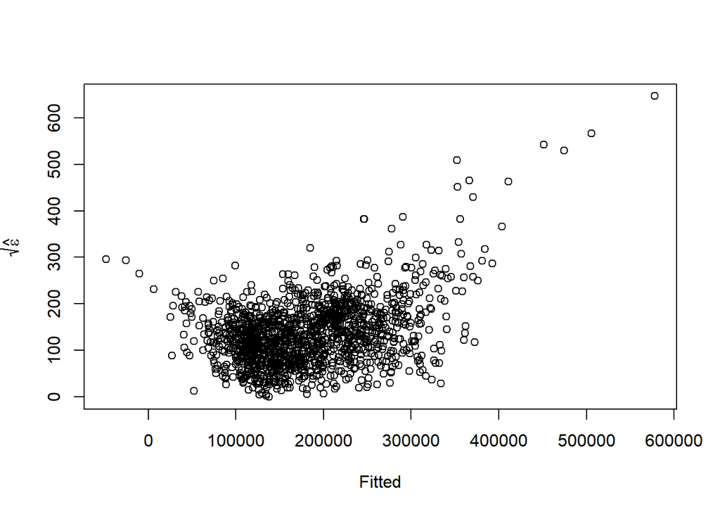

```r
plot(fitted(lmod), sqrt(abs(residuals(lmod))), xlab = "Fitted", ylab = expression(sqrt(hat(epsilon))))
```

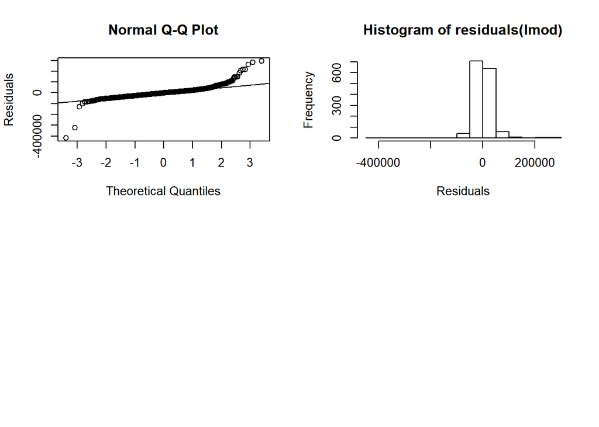

```r
par(mfrow=c(2,2))
qqnorm(residuals(lmod),ylab = "Residuals")
qqline(residuals(lmod))

hist(residuals(lmod),xlab = "Residuals")
```

# Performing the Durbin-Watson Statistic

```r
require(lmtest)
dwtest(lmod)
```

```
##
##  Durbin-Watson test
##
## data:  lmod
## DW = 1.998, p-value = 0.486
## alternative hypothesis: true autocorrelation is greater than 0
```

# 4 We are interested as well in checking for unusual observations

```r
hatv <- hatvalues(lmod)
head(hatv)
```

```
##           1           2           3           4           5           6
## 0.004862606 0.014410754 0.006026330 0.024220413 0.004476978 0.010600330
```

After performing the stepwise Regression, we found it interesting that we would only be using these variables that the stepwise regression indicated so as to build our linear regression model with,so we would name this train

```r
trainMdl <- lm(formula = newTrainingSet$SalePrice ~ LotArea + Neighborhood +
    BldgType + HouseStyle + OverallQual + OverallCond + YearBuilt +
    ExterQual + GrLivArea + FullBath + KitchenQual + GarageCars,
    data = newTrainingSet, na.action = na.omit)
summary(trainMdl)
```

```
##
## Call:
## lm(formula = newTrainingSet$SalePrice ~ LotArea + Neighborhood +
##     BldgType + HouseStyle + OverallQual + OverallCond + YearBuilt +
##     ExterQual + GrLivArea + FullBath + KitchenQual + GarageCars,
##     data = newTrainingSet, na.action = na.omit)
##
## Residuals:
##     Min      1Q  Median      3Q     Max
## -410362  -18819   -1010   14962  289979
##
## Coefficients:
##                  Estimate   Std. Error t value             Pr(>|t|)
## (Intercept)  -882045.3462  106002.0632  -8.321 < 0.0000000000000002 ***
## LotArea            0.7180       0.1015   7.071    0.000000000002391 ***
## Neighborhood     304.8680     165.0656   1.847               0.0650 .
## BldgType       -4837.3151     850.9239  -5.685    0.000000015818316 ***
## HouseStyle     -2418.8130     544.0473  -4.446    0.000009417875535 ***
## OverallQual    16110.2741    1244.3888  12.946 < 0.0000000000000002 ***
## OverallCond     4434.2300     970.9815   4.567    0.000005373845314 ***
## YearBuilt        467.2920      52.2628   8.941 < 0.0000000000000002 ***
## ExterQual     -15754.2474    2814.5037  -5.598    0.000000025974064 ***
## GrLivArea         56.7352       2.9494  19.236 < 0.0000000000000002 ***
## FullBath       -7607.9815    2512.0699  -3.029               0.0025 **
## KitchenQual   -12483.9505    2232.8382  -5.591    0.000000026937141 ***
## GarageCars     12604.1952    1750.6322   7.200    0.000000000000966 ***
## ---
## Signif. codes:  0 '***' 0.001 '**' 0.01 '*' 0.05 '.' 0.1 ' ' 1
##
## Residual standard error: 36370 on 1447 degrees of freedom
## Multiple R-squared:  0.7922, Adjusted R-squared:  0.7904
## F-statistic: 459.6 on 12 and 1447 DF,  p-value: < 0.00000000000000022
```

We could observe from the above that the R-squared value is preety high and it makes sense to me the predictor variables that the step function predicted to have high significance in the model, therefore, I would be using only these variables in the subsequent models.

```r
selectd_var <- c('LotArea', 'Neighborhood',
    'BldgType', 'HouseStyle','OverallQual', 'OverallCond','YearBuilt',
    'ExterQual', 'GrLivArea' ,'FullBath' ,'KitchenQual', 'GarageCars','SalePrice' )
trainSelectVar <- newTrainingSet[,selectd_var]
head(trainSelectVar)
```

```
##   LotArea Neighborhood BldgType HouseStyle OverallQual OverallCond
## 1    8450            6        1          6           7           5
## 2    9600           25        1          3           6           8
## 3   11250            6        1          6           7           5
## 4    9550            7        1          6           7           5
## 5   14260           14        1          6           8           5
## 6   14115           12        1          1           5           5
##   YearBuilt ExterQual GrLivArea FullBath KitchenQual GarageCars SalePrice
## 1      2003         2      1710        2           2          2    208500
## 2      1976         3      1262        2           3          2    181500
## 3      2001         2      1786        2           2          2    223500
## 4      1915         3      1717        1           2          3    140000
## 5      2000         2      2198        2           2          3    250000
## 6      1993         3      1362        1           3          2    143000
```

```r
attach(trainSelectVar)
library(car)
```

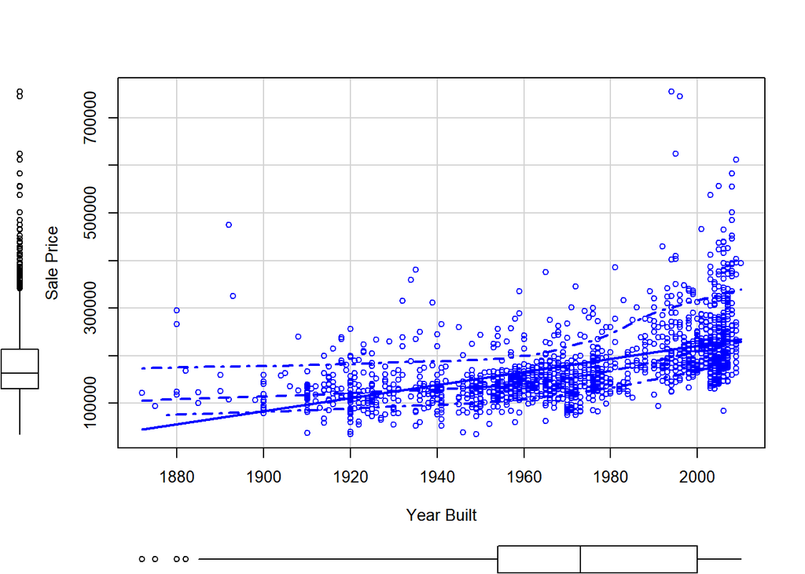

```r
scatterplot(SalePrice ~ YearBuilt, data = trainSelectVar, xlab = "Year Built", ylab = "Sale Price", grid = TRUE)
```

```r
test_set <- read.csv("C:/Users/HP Laptop/Desktop/stat5120project/test.csv", na.strings = "NA", header = TRUE)
# Converting Factors to Numeric
test_set$ExterQual <- as.numeric(factor(test_set$ExterQual, levels = c("Ex","Gd","TA","Fa","Po"),labels = c(5,4,3,2,1), ordered = T))
test_set$HeatingQC <- as.numeric(factor(test_set$HeatingQC, levels = c("Ex","Gd","TA","Fa","Po"),labels = c(5,4,3,2,1), ordered = T))
test_set$CentralAir <- as.numeric(factor(test_set$CentralAir, levels = c("N","Y"),labels = c(0,1),ordered = T))
test_set$KitchenQual <- as.numeric(factor(test_set$KitchenQual, levels = c("Ex","Gd","TA","Fa","Po"),labels = c(5,4,3,2,1), ordered = T))

test_set$MSZoning <-as.numeric(factor(test_set$MSZoning))
test_set$Neighborhood <- as.numeric(factor(test_set$Neighborhood))
test_set$Utilities <- as.numeric(factor(test_set$Utilities))
test_set$BldgType <- as.numeric(factor(test_set$BldgType))
test_set$HouseStyle <- as.numeric(factor(test_set$HouseStyle))


selectd_var <- c('LotArea', 'Neighborhood',
    'BldgType', 'HouseStyle','OverallQual', 'OverallCond','YearBuilt',
    'ExterQual', 'GrLivArea' ,'FullBath' ,'KitchenQual', 'GarageCars')
testSelectVar <- test_set[,selectd_var]
head(testSelectVar)
```

```
##   LotArea Neighborhood BldgType HouseStyle OverallQual OverallCond
## 1   11622           13        1          3           5           6
## 2   14267           13        1          3           6           6
## 3   13830            9        1          5           5           5
## 4    9978            9        1          5           6           6
## 5    5005           22        5          3           8           5
## 6   10000            9        1          5           6           5
##   YearBuilt ExterQual GrLivArea FullBath KitchenQual GarageCars
## 1      1961         3       896        1           3          1
## 2      1958         3      1329        1           2          1
## 3      1997         3      1629        2           3          2
## 4      1998         3      1604        2           2          2
## 5      1992         2      1280        2           2          2
## 6      1993         3      1655        2           3          2
```

```r
pred <- predict(trainMdl,testSelectVar, type = "response")
testPrediction <- data.frame("Id" =  test_set$Id, "SalePrice" = pred)
testModelOutput <- cbind(testSelectVar,pred)
head(testModelOutput)
```

```
##   LotArea Neighborhood BldgType HouseStyle OverallQual OverallCond
## 1   11622           13        1          3           5           6
## 2   14267           13        1          3           6           6
## 3   13830            9        1          5           5           5
## 4    9978            9        1          5           6           6
## 5    5005           22        5          3           8           5
## 6   10000            9        1          5           6           5
##   YearBuilt ExterQual GrLivArea FullBath KitchenQual GarageCars     pred
## 1      1961         3       896        1           3          1 112801.1
## 2      1958         3      1329        1           2          1 166458.8
## 3      1997         3      1629        2           3          2 167300.7
## 4      1998         3      1604        2           2          2 196612.5
## 5      1992         2      1280        2           2          2 204848.3
## 6      1993         3      1655        2           3          2 180267.1
```

I decided to scale both the training and the test set and then try to perform different model to compare which works best

```r
scaleTrain <- data.frame(scale(trainSelectVar))
scaleTest <- data.frame(scale(testModelOutput))
head(scaleTrain)
```

```
##       LotArea Neighborhood   BldgType HouseStyle OverallQual OverallCond
## 1 -0.20707076   -1.2131985 -0.4115498  1.0263376  0.65125610  -0.5170227
## 2 -0.09185490    2.0106857 -0.4115498 -0.5432709 -0.07181151   2.1788812
## 3  0.07345481   -1.2131985 -0.4115498  1.0263376  0.65125610  -0.5170227
## 4 -0.09686428   -1.0435204 -0.4115498  1.0263376  0.65125610  -0.5170227
## 5  0.37501979    0.1442264 -0.4115498  1.0263376  1.37432370  -0.5170227
## 6  0.36049258   -0.1951298 -0.4115498 -1.5896765 -0.79487911  -0.5170227
##    YearBuilt  ExterQual  GrLivArea  FullBath KitchenQual GarageCars
## 1  1.0506338 -1.0519418  0.3702066  0.789470  -0.7357422  0.3116179
## 2  0.1566800  0.6893677 -0.4823466  0.789470   0.7708267  0.3116179
## 3  0.9844150 -1.0519418  0.5148362  0.789470  -0.7357422  0.3116179
## 4 -1.8629933  0.6893677  0.3835277 -1.025689  -0.7357422  1.6497417
## 5  0.9513056 -1.0519418  1.2988806  0.789470  -0.7357422  1.6497417
## 6  0.7195398  0.6893677 -0.2920446 -1.025689   0.7708267  0.3116179
##      SalePrice
## 1  0.347154270
## 2  0.007285824
## 3  0.535970074
## 4 -0.515104565
## 5  0.869544659
## 6 -0.477341404
```

So lets build a regression model on the scaled training model

```r
scaletrainMdl <- lm(formula = scaleTrain$SalePrice ~ LotArea + Neighborhood +
    BldgType + HouseStyle + OverallQual + OverallCond + YearBuilt +
    ExterQual + GrLivArea + FullBath + KitchenQual + GarageCars,
    data = scaleTrain, na.action = na.omit)
summary(scaletrainMdl)
```

```
##
## Call:
## lm(formula = scaleTrain$SalePrice ~ LotArea + Neighborhood +
##     BldgType + HouseStyle + OverallQual + OverallCond + YearBuilt +
##     ExterQual + GrLivArea + FullBath + KitchenQual + GarageCars,
##     data = scaleTrain, na.action = na.omit)
##
## Residuals:
##     Min      1Q  Median      3Q     Max
## -5.1655 -0.2369 -0.0127  0.1883  3.6502
##
## Coefficients:
##                            Estimate             Std. Error t value
## (Intercept)  -0.0000000000000001248  0.0119808490581649225   0.000
## LotArea       0.0902053071020698927  0.0127575800349953410   7.071
## Neighborhood  0.0226168984090329254  0.0122455360206153250   1.847
## BldgType     -0.0729640159734764593  0.0128349760016241311  -5.685
## HouseStyle   -0.0581941467785929839  0.0130892165747353972  -4.446
## OverallQual   0.2804601145609527113  0.0216632828447516045  12.946
## OverallCond   0.0621129493713204334  0.0136011272730721250   4.567
## YearBuilt     0.1776577502603119418  0.0198695625382158021   8.941
## ExterQual    -0.1138855910032197383  0.0203457140912486657  -5.598
## GrLivArea     0.3752808184932521773  0.0195093802052831410  19.236
## FullBath     -0.0527596323447836607  0.0174206368464016707  -3.029
## KitchenQual  -0.1043061949660510912  0.0186558615469337025  -5.591
## GarageCars    0.1185675666219115215  0.0164681835099537918   7.200
##                          Pr(>|t|)
## (Intercept)                1.0000
## LotArea         0.000000000002391 ***
## Neighborhood               0.0650 .
## BldgType        0.000000015818316 ***
## HouseStyle      0.000009417875535 ***
## OverallQual  < 0.0000000000000002 ***
## OverallCond     0.000005373845314 ***
## YearBuilt    < 0.0000000000000002 ***
## ExterQual       0.000000025974064 ***
## GrLivArea    < 0.0000000000000002 ***
## FullBath                   0.0025 **
## KitchenQual     0.000000026937141 ***
## GarageCars      0.000000000000966 ***
## ---
## Signif. codes:  0 '***' 0.001 '**' 0.01 '*' 0.05 '.' 0.1 ' ' 1
##
## Residual standard error: 0.4578 on 1447 degrees of freedom
## Multiple R-squared:  0.7922, Adjusted R-squared:  0.7904
## F-statistic: 459.6 on 12 and 1447 DF,  p-value: < 0.00000000000000022
```

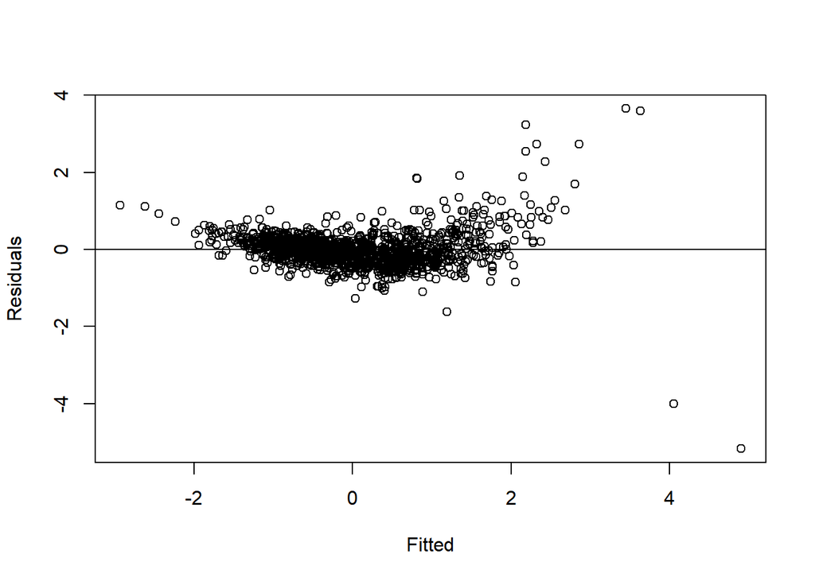

```r
plot(fitted(scaletrainMdl), residuals(scaletrainMdl), xlab = "Fitted", ylab = "Residuals")
abline(h=0)
```

```r
RSS <- c(crossprod(scaletrainMdl$residuals))
MSE <- RSS/length(scaletrainMdl$residuals)
RMSE <- sqrt(MSE)
print(RMSE)
```

```
## [1] 0.4557449
```

We see that the fit of this model is already very good in terms of R- squared,

```r
summary(scaletrainMdl)$r.squared
```

```
## [1] 0.7921542
```

## 4.1 Lasso regression model

The elastic-net penalty is controlled by alpha, and bridges the gap between lasso (alpha=1) and ridge (alpha=0). The tuning parameter lambda controls the overall strength of the penalty. It is known that the ridge penalty shrinks the coefficients of correlated predictors towards each other while the lasso tends to pick one of them and discard the others.

Below, I am using caret cross validation to find the best value for lambda, which is the only hyperparameter that needs to be tuned for the lasso model.

### 4.1.1 Ridge Model

To overcome overfitting, I used the ridge model

```r
selectd_var <- c('LotArea', 'Neighborhood',
    'BldgType', 'HouseStyle','OverallQual', 'OverallCond','YearBuilt',
    'ExterQual', 'GrLivArea' ,'FullBath' ,'KitchenQual', 'GarageCars','SalePrice' )
sctrainSelectVar <- scaleTrain[,selectd_var]
#head(trainSelectVar)

yTrainSelector <- as.matrix(sctrainSelectVar[1:1460,13])

xTrainSelector <- as.matrix(sctrainSelectVar[1:1460,1:12])
head(xTrainSelector)
```

```
##       LotArea Neighborhood   BldgType HouseStyle OverallQual OverallCond
## 1 -0.20707076   -1.2131985 -0.4115498  1.0263376  0.65125610  -0.5170227
## 2 -0.09185490    2.0106857 -0.4115498 -0.5432709 -0.07181151   2.1788812
## 3  0.07345481   -1.2131985 -0.4115498  1.0263376  0.65125610  -0.5170227
## 4 -0.09686428   -1.0435204 -0.4115498  1.0263376  0.65125610  -0.5170227
## 5  0.37501979    0.1442264 -0.4115498  1.0263376  1.37432370  -0.5170227
## 6  0.36049258   -0.1951298 -0.4115498 -1.5896765 -0.79487911  -0.5170227
##    YearBuilt  ExterQual  GrLivArea  FullBath KitchenQual GarageCars
## 1  1.0506338 -1.0519418  0.3702066  0.789470  -0.7357422  0.3116179
## 2  0.1566800  0.6893677 -0.4823466  0.789470   0.7708267  0.3116179
## 3  0.9844150 -1.0519418  0.5148362  0.789470  -0.7357422  0.3116179
## 4 -1.8629933  0.6893677  0.3835277 -1.025689  -0.7357422  1.6497417
## 5  0.9513056 -1.0519418  1.2988806  0.789470  -0.7357422  1.6497417
## 6  0.7195398  0.6893677 -0.2920446 -1.025689   0.7708267  0.3116179
```

```r
head(yTrainSelector)
```

```
##              [,1]
## [1,]  0.347154270
## [2,]  0.007285824
## [3,]  0.535970074
## [4,] -0.515104565
## [5,]  0.869544659
## [6,] -0.477341404
```

```r
library(glmnet)
```

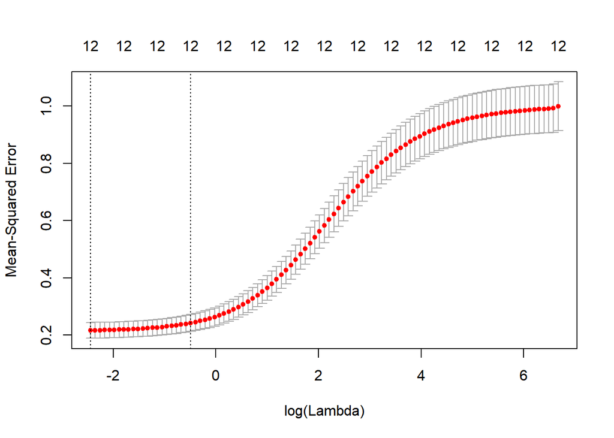

```r
fit <- glmnet(xTrainSelector,yTrainSelector)
cvfit_ridge <- cv.glmnet(xTrainSelector, yTrainSelector, alpha = 0)
plot(cvfit_ridge)
```

```r
print(cvfit_ridge$lambda.min)
```

```
## [1] 0.0867804
```

```r
ridge_coef <- cvfit_ridge$glmnet.fit$beta[,cvfit_ridge$glmnet.fit$lambda == cvfit_ridge$lambda.min]
c <- as.matrix(coef(fit, s= 0.06789084))
yHat <- predict(fit,xTrainSelector,s= 0.06789084)
dof <- length(yTrainSelector)-length(c)
rse <- sqrt(sum((yTrainSelector - yHat)^2)/dof)
rse
```

```
## [1] 0.4821282
```

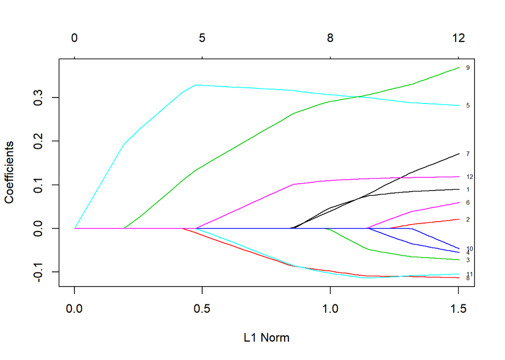

```r
plot(fit, label =T)
```

```r
my_control <- trainControl(method ="cv", number = 5)
lassoGrid <- expand.grid(alpha = 1, lambda = seq(0.001,0.1, by = 0.0005))

lasso_mod <- train(xTrainSelector, y = trainSelectVar$SalePrice[!is.na(trainSelectVar$SalePrice)], method = "glmnet", trControl = my_control,tuneGrid = lassoGrid)
lasso_mod$bestTune
```

```
##     alpha lambda
## 199     1    0.1
```

## 4.3 References.

Our gratitude goes to Dr. Matt Jones, who taught us Regression Analysis as well as explained all the concepts in the topic to us, which gave us all the know-how to use in this project. We all appreciate the richness of the text, Linear Models with R by Faraway which was a very great resource for this project -The data was gotten from Kaggle https://www.kaggle.com/c/house-prices-advanced-regression-techniques